# The beauty of data manipulation with data.table

2018-05-14

## Intro

## About

János Divényi

- Economist by training - currently PhD candidate at CEU
- 5+ years experience in R
- lead data scientist at Emarsys

Emarsys

- largest independent marketing platform company in the world
- 350 million daily interactions
- true personalization at scale

## Warm up

wifi: CEU Guest, pwd: Budapest1991

https://b.socrative.com/login/student/

Room Name: ERUM

## Pre-requisites

- skilled in data manipulation in R (using base R or tidyverse)
- no knowledge of data.table

## Content

1. Introduction
2. The power of data.table
3. Winning points
4. Some examples for advanced usage

Live coding on a case study: sales from one of our clients, an e-commerce fashion business (sample)

## Data

Download the data (2 large csv files) from divenyijanos.github.io/pages/talks

## Setup

```r
library(data.table)  # 1.11.2
library(magrittr)  # 1.5
library(ggplot2)  # 2.2.2
library(dplyr)  # 0.7.4
options(datatable.print.class = TRUE)
```

Make sure you have the required packages.

## Load the data

```r
data_file <- '../data/erum_workshop_dt_sales.csv'
sales <- fread(data_file)
```

## Benchmark

```r
plotMicrobenchmark <- function(microbenchmark_result, x) {
    microbenchmark_result$expr <- factor(microbenchmark_result$expr, labels = x)
    p <- ggplot(microbenchmark_result, aes(expr, time/10^6, color = expr)) +
        geom_boxplot() +
        scale_y_log10() +
        scale_color_discrete(guide = guide_legend(title = "Method")) +
        labs(x = '', y = 'time (ms) - log scale')
    print(p)
}
```

## Benchmark

```r
read_benchmark <- microbenchmark::microbenchmark(
    read.csv(data_file),
    readr::read_csv(data_file),
    fread(data_file)
)
```

## Benchmark

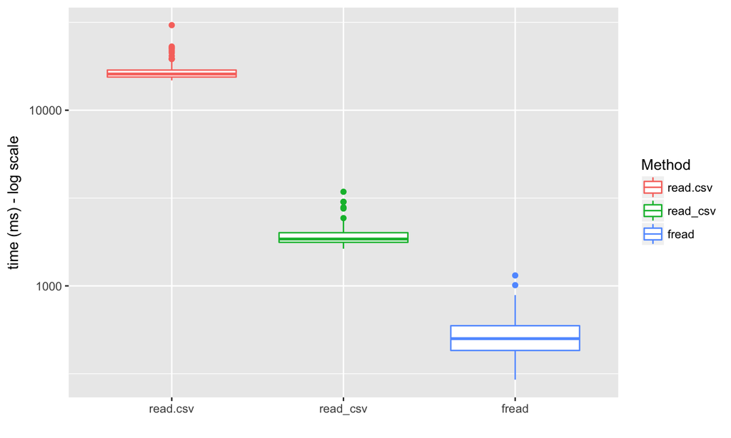

```r
plotMicrobenchmark(read_benchmark, c('read.csv', 'read_csv', 'fread'))
```

Note: `readr::read_csv()` parses date column as class `Date`

## Look at the data

```r
sales
class(sales)
```

## Syntax

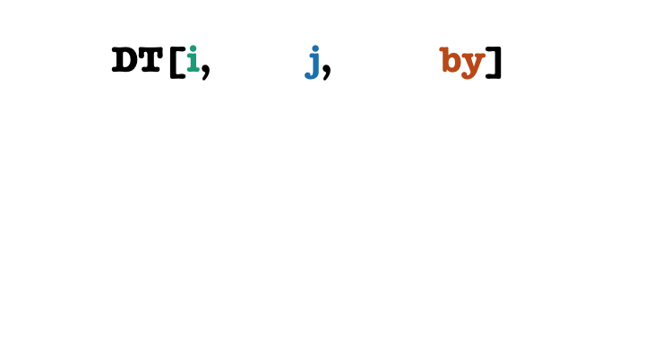

## Syntax

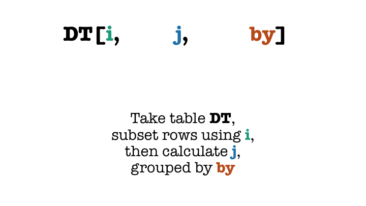

## Syntax

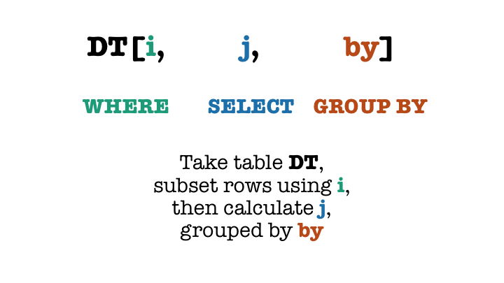

## Subset rows using i…

```r
sales[1:10]
sales[customer_lifecycle_status == 'Lead']
```

Similar to `dplyr`, the environment is the data.table itself.

## …then calculate j…

```r
sales[, sum(sales_amount)]
sales[, list(min(purchase_date), max(purchase_date))]
```

## …grouped by by

```r
sales[, sum(sales_amount), by = purchase_date]
sales[, sum(sales_amount), by = list(customer_lifecycle_status, purchase_date)]
sales[, sum(sales_amount), by = (purchase_date > '2016-12-31')]
sales[, sum(sales_amount), by = list(in_2017 = purchase_date > '2016-12-31')]
```

## TASK: Calculate the mean sales by customer lifecycle status

```r
sales[, mean(sales_amount), by = customer_lifecycle_status]
```

## Select columns

```r
sales[, sales_amount]  # returns vector
sales[, list(sales_amount)]  # returns data.table
sales[, .(sales_amount)]  # shortcut for list()
sales[, c('sales_amount')]  # data.frame-way but returns data.table
sales[, c('contact_id', 'sales_amount')]  # same as with data.frame
```

## Select aggregates

```r
sales[, .(sum(sales_amount), sd(sales_amount))]
sales[, .(sum_sales_amount = sum(sales_amount), sd_sales_amount = sd(sales_amount))]
sales[, .(mean_sales = mean(sales_amount)), by = customer_lifecycle_status]
```

## efficient data.table functions

```r
sales[, .N, by = customer_lifecycle_status]
sales[, uniqueN(contact_id), by = customer_lifecycle_status]
```

## TASK: Create a table that contains each buyer with the number of orders they made

```r
sales[, .N, by = contact_id]
```

## TASK: Create a table that contains each buyer of 2017 with the number of orders they made

```r
sales[purchase_date >= '2017-01-01', .N, by = contact_id]
```

## TASK: Create a summary table by customer_lifecycle_status: number of purchases, sum of sales, number of buyers

```r
sales[,
    .(
        sum_sales = sum(sales_amount),
        num_purchases = .N,
        num_buyers = uniqueN(contact_id)
    ),
    by = customer_lifecycle_status
]
```

## You can really do whatever calculation in j

```r
sales[, table(customer_lifecycle_status)]
sales[, hist(sales_amount)]
sales[, lm(sales_amount ~ customer_lifecycle_status)]
```

## The power of data.table

## Combine with plots (using pipe from magrittr)

```r
sales[, .(mean_sales = mean(sales_amount)), by = customer_lifecycle_status] %>%
    ggplot(aes(customer_lifecycle_status, mean_sales)) + geom_col()
```

## Chain operations

```r
sales[, .(daily_sales = sum(sales_amount)), by = purchase_date][daily_sales > 400000]
sales[, .(daily_sales = sum(sales_amount)), by = purchase_date] %>%
    .[daily_sales > 400000]
```

## TASK: Select days when someone spent more than 10k

```r
sales[, .(max_sales = max(sales_amount)), by = purchase_date] %>%
    .[max_sales > 10000]
```

## Modify in-place

```r
sales[, a := 'a']
sales
sales[, a := NULL]
sales
```

## Detour: handling dates

```r
sales[, purchase_date := as.Date(purchase_date)]  # DON'T DO! very very slow
```

Parse the character date with `fasttime:fastPOSIXct()` first

## Benchmark

```r
date_conversion_benchmark <- microbenchmark::microbenchmark(
    copy(sales)[, purchase_date := as.Date(purchase_date, '%Y-%m-%d')],
    copy(sales)[, purchase_date := as.Date(lubridate::fast_strptime(purchase_date, '%Y-%m-%d'))],
    copy(sales)[, purchase_date := as.Date(fasttime::fastPOSIXct(purchase_date))]
)
```

## Benchmark

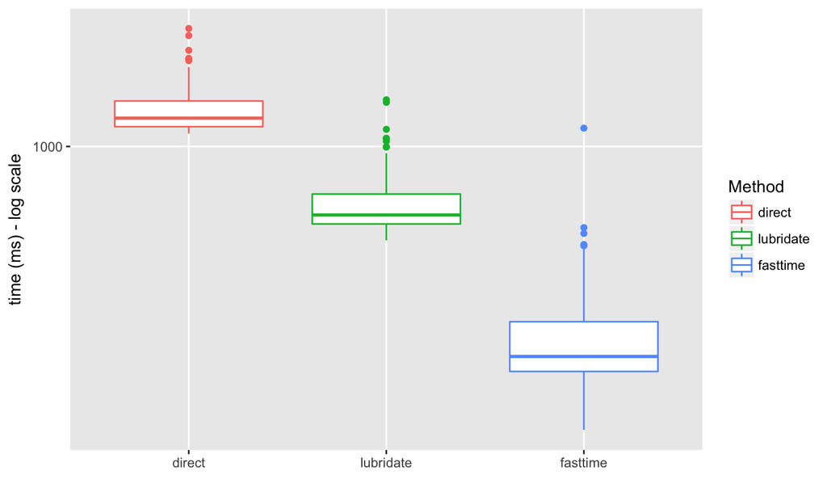

```r
plotMicrobenchmark(date_conversion_benchmark, c('direct', 'lubridate', 'fasttime'))
```

## Detour: data.table’s internal Date class

```r
sales_date <- copy(sales)[, purchase_date := as.Date(fasttime::fastPOSIXct(purchase_date))]
# integer storage for fast sorting
sales[, purchase_date := as.IDate(fasttime::fastPOSIXct(purchase_date))]
```

## Benchmark

```r
order_benchmark <- microbenchmark::microbenchmark(
    sales_date[order(purchase_date)],
    sales[order(purchase_date)]
)
```

## Benchmark

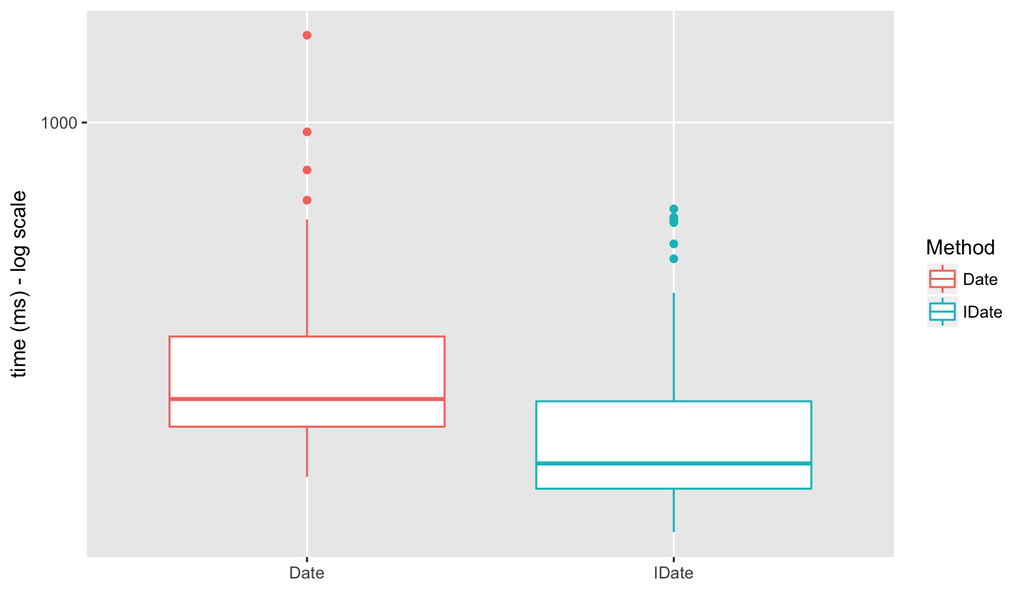

```r
plotMicrobenchmark(order_benchmark, c('Date', 'IDate'))
```

## TASK: Create a new ‘year’ and ‘month’ variable

```r
sales[, year := year(purchase_date)]
sales[, month := month(purchase_date)]
```

## TASK: Count the number of orders by customer lifecycle status and year

```r
sales[, .N, by = .(customer_lifecycle_status, year)]
sales[, table(customer_lifecycle_status, year)]
```

## Add grouped variable

```r
sales[, daily_sum := sum(sales_amount), by = purchase_date]
sales[purchase_date > '2016-12-31', daily_sum_in_2017 := sum(sales_amount), by = purchase_date]
```

## TASK: Add the lifecycle-specific average sales amount to each purchase

```r
sales[, lifecycle_average_sales := mean(sales_amount), by = customer_lifecycle_status]
```

## Add multiple variables at once

```r
sales[, c('year', 'month') := .(year(purchase_date), month(purchase_date))]
sales[, `:=`(year = year(purchase_date), month = month(purchase_date))]
```

## Remove more variables at once

```r
sales[, c('daily_sum', 'daily_sum_in_2017') := NULL]
```

## Do the same calculation for each columns

```r
sales[, lapply(.SD, uniqueN)]
```

## Do the same calculation for relevant columns

```r
sales[, lapply(.SD, median), .SDcols = c('quantity', 'sales_amount')]
```

## More complicated calculation

```r
sales[,
    lapply(.SD, function(x) quantile(x, p = 0.75)),
    by = customer_lifecycle_status,
    .SDcols = c('quantity', 'sales_amount')
]
```

## TASK: Find the maximum quantity and spending for each year

```r
sales[, lapply(.SD, max), by = year, .SDcols = c('sales_amount', 'quantity')]
```

## Find the orders with the maximum spending for each year

```r
sales[
    sales_amount == max(sales_amount),
    .(contact_id, sales_amount),
    by = year  # by only applies to calculation in j!
]
sales[order(-sales_amount), lapply(.SD, head, n = 1), by = year]
sales[order(-sales_amount), .SD[1], by = year]
```

## repeated update: use set(DT, i , j, value)

```r
for (j in c('sales_amount', 'quantity')) {
    set(sales, which(sales[[j]] < 0), j, NA)
}
```

## Select within function: get()

```r
returnMax <- function(dt, column) {
    dt[, max(get(column))]
}
returnMax(sales, 'purchase_date')
returnMax(sales, 'quantity')
```

## Purchase frequency

```r
sales[
    order(contact_id, purchase_date),
    days_since_last_purchase := purchase_date - shift(purchase_date),
    by = contact_id
]
sales %>%
    ggplot(aes(is.na(days_since_last_purchase))) +
    geom_bar() +
    labs(x = 'First purchase')
sales[!is.na(days_since_last_purchase)] %>%
    ggplot(aes(days_since_last_purchase)) +
    geom_histogram() +
    labs(x = 'Days since last purchase')
```

## Reshape: max value by year, customer_lifecycle_status

```r
sales[, max(sales_amount), by = .(customer_lifecycle_status, year)] %>%
    dcast(customer_lifecycle_status ~ year)
```

## Reshape: melt (opposite of dcast)

```r
sales[, max(sales_amount), by = .(customer_lifecycle_status, year)] %>%
    dcast(customer_lifecycle_status ~ year) %>%
    melt(id.vars = 'customer_lifecycle_status')
```

## TASK: plot daily sales and quantity in facets

```r
sales[, lapply(.SD, sum), by = purchase_date, .SDcols = c('sales_amount', 'quantity')] %>%
    melt(id.vars = 'purchase_date') %>%
    ggplot(aes(purchase_date, value)) +
        geom_line() +
        facet_wrap(~ variable, ncol = 1, scales = 'free_y')
```

## Key

```r
sales[, .(yearly_sales = sum(sales_amount)), by = year]
sales[, .(yearly_sales = sum(sales_amount)), keyby = year]
```

Sorts on the key by reference

## Key’s usage

```r
setkey(sales, customer_lifecycle_status)
sales
sales['Lead']
```

## Key’s usage in merge

```r
status_sales <- sales[,
    .(sum_sales_by_status = sum(sales_amount)),
    keyby = customer_lifecycle_status
]
status_sales[sales]

merge(sales, status_sales, by = 'customer_lifecycle_status')  # works as well
```

## Winning points of data.table

## Refresh quiz

https://b.socrative.com/login/student/

Room Name: ERUM

## Create corresponding table formats for comparison

```r
sales_df <- as.data.frame(sales_date)
sales_tibble <- tibble::as.tibble(sales_date)
```

## Count unique values - benchmark

```r
unique_benchmark <- microbenchmark::microbenchmark(
    length(unique(sales_df$contact_id)),
    summarise(sales_tibble, n_distinct(contact_id)),
    sales[, uniqueN(contact_id)]
)
```

## Count unique values - benchmark

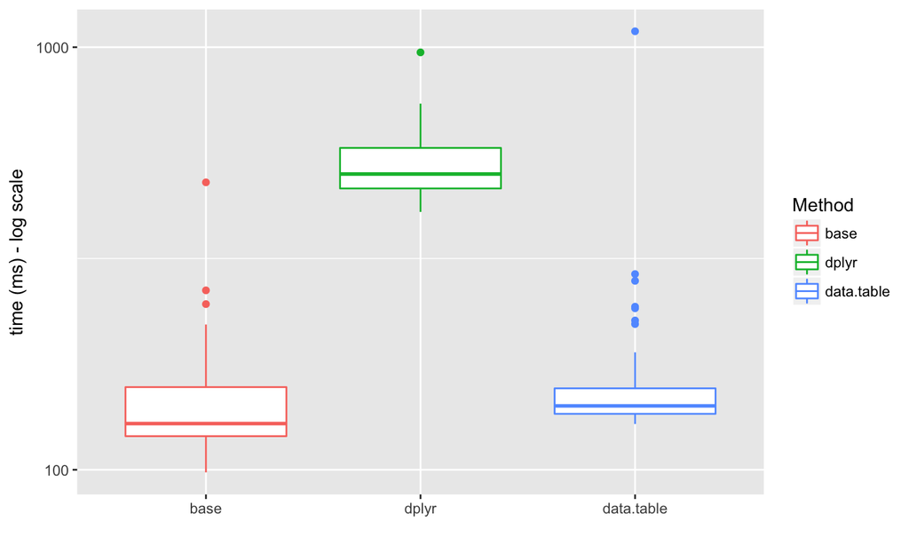

```r
plotMicrobenchmark(unique_benchmark, x = c('base', 'dplyr', 'data.table'))
```

## Aggregate by groups - benchmark

```r
aggregate_benchmark <- microbenchmark::microbenchmark(
    aggregate(
        sales_df$sales_amount,
        by = list(sales_df$customer_lifecycle_status, sales_df$purchase_date),
        FUN = mean
    ),
    sales_tibble %>%
        group_by(customer_lifecycle_status, purchase_date) %>%
        summarise(mean(sales_amount)),
    sales[, mean(sales_amount), by = .(customer_lifecycle_status, purchase_date)]
)
```

## Aggregate by groups - benchmark

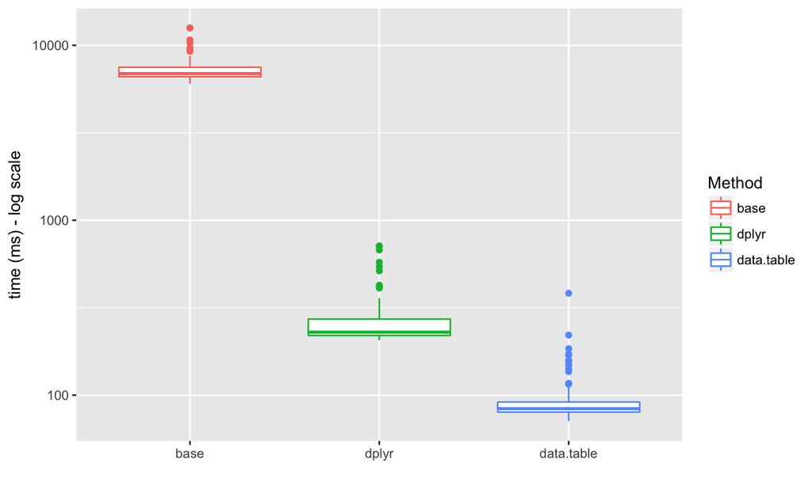

```r
plotMicrobenchmark(aggregate_benchmark, x = c('base', 'dplyr', 'data.table'))
```

## Create new variable - benchmark

```r
new_var_benchmark <- microbenchmark::microbenchmark(
    sales_df$sales_squared <- sales_df$sales_amount^2,
    sales_tibble %<>% mutate(sales_squared = sales_amount^2),
    sales[, sales_squared := sales_amount^2]
)
```

## Create new variable - benchmark

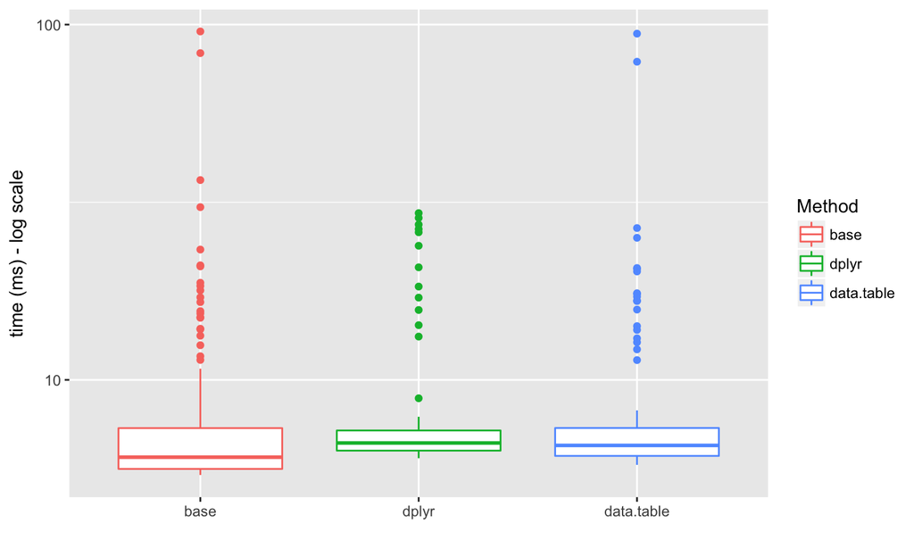

```r
plotMicrobenchmark(new_var_benchmark, x = c('base', 'dplyr', 'data.table'))
```

## Replace values at specific indices - benchmark (ms)

```r
columns <- c('sales_amount', 'quantity')
replace_benchmark <- microbenchmark::microbenchmark(
    sales_df[, columns][sales_df[, columns] < 0] <- NA,
    mutate_at(sales_tibble, columns, funs(replace(., . < 0, NA))),
    for (j in columns) {
        set(sales, which(sales[[j]] < 0), j, NA)
    }
)
```

## Replace values at specific indices - benchmark

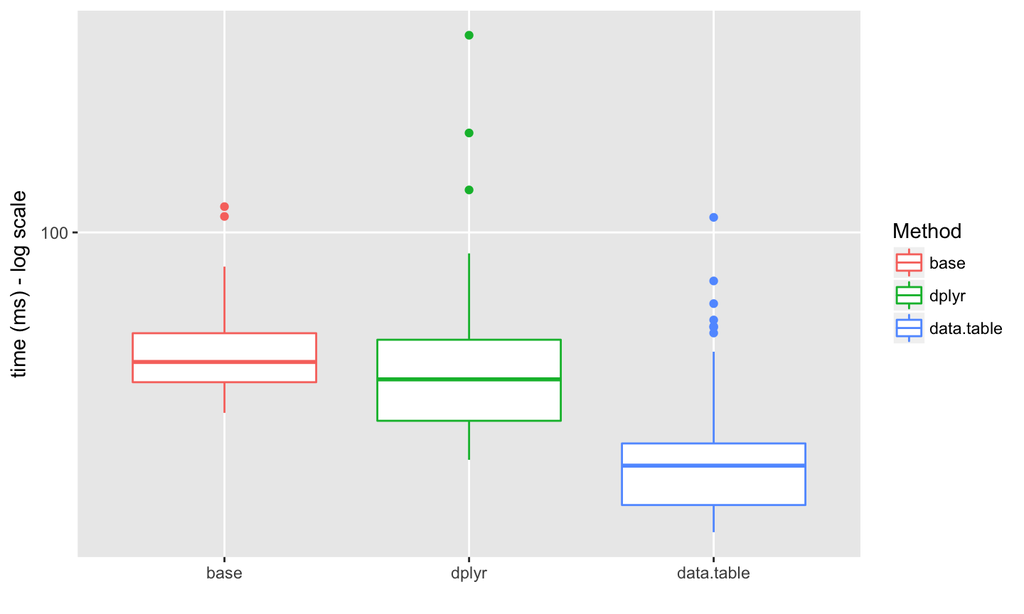

```r
plotMicrobenchmark(replace_benchmark, x = c('base', 'dplyr', 'data.table'))
```

## Lookup for specific values - benchmark

```r
lookup_benchmark <- microbenchmark::microbenchmark(
    sales_df[sales_df$order_id == 2430931,],
    filter(sales, order_id == 2430931),
    sales[order_id == 2430931]
)
```

## Lookup for specific values - benchmark

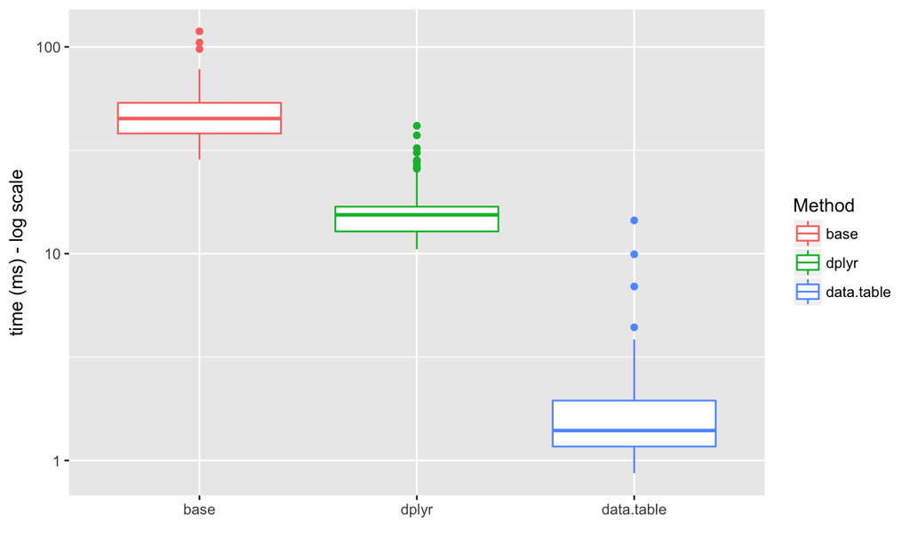

```r
plotMicrobenchmark(lookup_benchmark, c('base', 'dplyr', 'data.table'))
```

## data.table vs dplyr - let the experts speak

[Excellent SO thread with Matt, Hadley and others](https://stackoverflow.com/questions/21435339/data-table-vs-dplyr-can-one-do-something-well-the-other-cant-or-does-poorly)

## Some examples for advanced usage

## Case #1: Attribute purchases to web sessions

## Use web session data as well

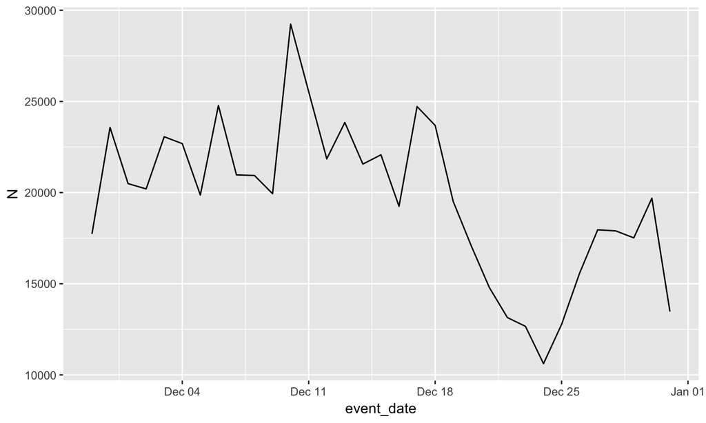

```r
web <- fread('../data/erum_workshop_dt_web.csv')
web[, event_date := as.IDate(fasttime::fastPOSIXct(event_date))]
web[, .N, by = event_date] %>% ggplot(aes(event_date, N)) + geom_line()
```

## Attribution

```r
sales[contact_id == 7226]
web[contact_id == 7226]
```

```r
sales[, join_date := as.IDate(purchase_date)]
web[, join_date := event_date]
setkey(sales, contact_id, join_date)
setkey(web, contact_id, join_date)
merged <- sales[web, roll = -Inf]  # each web session to the nearest following purchase
```

```r
merged
merged[contact_id == 7226]
merged[contact_id == 4775737]
```

## Share of converted sessions

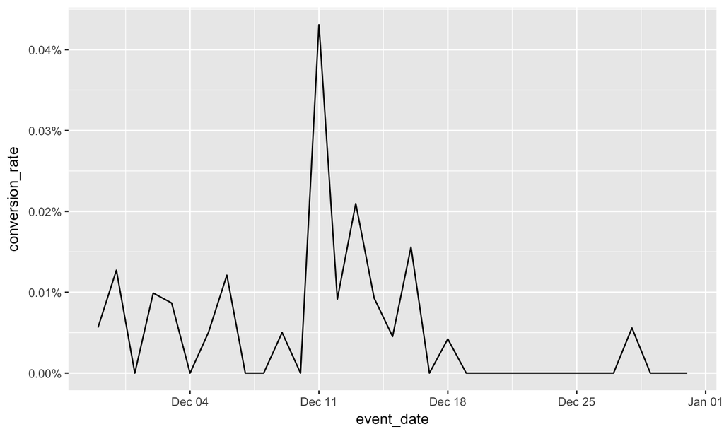

```r
merged[, .(conversion_rate = mean(!is.na(purchase_date))), by = event_date] %>%
    ggplot(aes(event_date, conversion_rate)) +
    geom_line() +
    scale_y_continuous(labels = scales::percent)
```

## Set rolling window

```r
# each web session to the nearest following purchase within a week
merged <- sales[web, roll = -7]

merged[contact_id == 7226]
merged[contact_id == 4775737]
```

## Case #2: Regression by groups

## Estimate a separate model for each group

```r
data_for_plot <- sales[,
        .(daily_sales = sum(sales_amount)),
        by = .(purchase_date, year, month)
    ][,
        fitted := fitted(lm(log(daily_sales) ~ month)),
        by = year
    ]
```

Instead of `lm()` you can use what you want.

## Estimate a separate model for each group

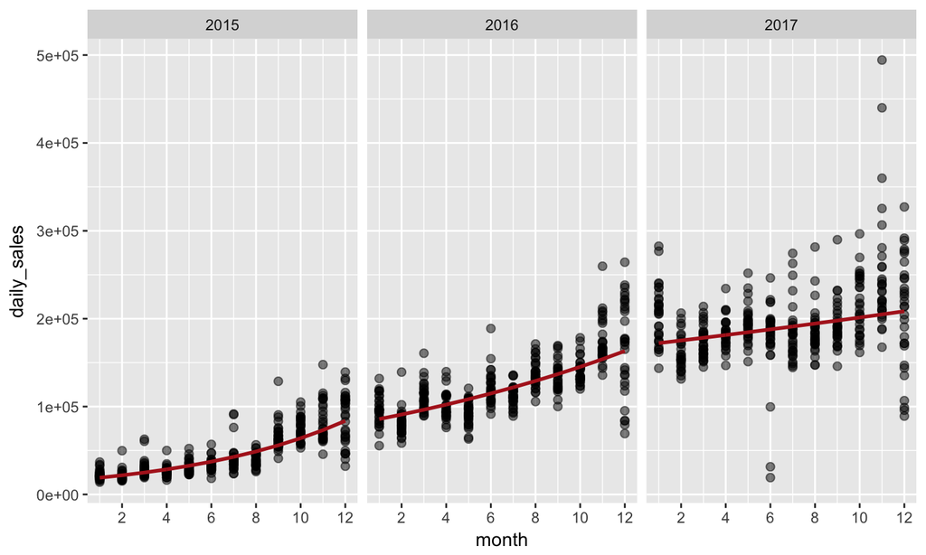

```r
ggplot(data_for_plot, aes(month, daily_sales)) +
    geom_point(size = 2, alpha = 0.5) +
    geom_line(aes(y = exp(fitted)), size = 1, color = 'firebrick') +
    scale_x_continuous(breaks = scales::pretty_breaks(6)) +
    facet_wrap(~year)
```

## Case #3: Data.table within function

## Modifier function

```r
createSquares <- function(dt, columns) {
    new_column_names <- paste(columns, 'square', sep = '_')
    dt[, (new_column_names) := lapply(.SD, function(x) x^2), .SDcols = columns]
}
createSquares(sales, c('sales_amount', 'quantity'))
sales
```

## Modifier function accepting by parameter

```r
createAvg <- function(dt, column, by = NULL) {
    new_column_name <- paste('avg', column, sep = '_')
    if (!is.null(by)) {
        new_column_name <- paste(new_column_name, 'by', by, sep = '_')
    }
    dt[, (new_column_name) := mean(get(column)), by = by]
}
createAvg(sales, 'sales_amount')
sales
createAvg(sales, 'quantity', by = 'customer_lifecycle_status')
sales
```

## TASK: Plot a graph of the share of contacts vs share of revenue for 2017

```r
sales[
    year == 2017, .(revenue = sum(sales_amount), count = 1), by = contact_id
][
    order(-revenue),
    .(
        share_of_revenue = cumsum(revenue)/sum(revenue),
        share_of_contacts = cumsum(count)/.N
    )
][
    seq(1, .N, 100)  # trick to make the plotting faster
] %>%
ggplot(aes(share_of_contacts, share_of_revenue)) + geom_line()
```

## Thanks

## Sources

[Cheatsheet](https://s3.amazonaws.com/assets.datacamp.com/img/blog/data+table+cheat+sheet.pdf)

fread

[efficient reshaping](https://cran.r-project.org/web/packages/data.table/vignettes/datatable-reshape.html)

[Rolling joins](https://r-norberg.blogspot.hu/2016/06/understanding-datatable-rolling-joins.html)

[Stackoverflow](https://stackoverflow.com/questions/tagged/r+data.table)

## Thanks

@paljenczy

@MattDowle

Stackoverflow guys, esp. @DavidArenburg, @akrun

## Exit quiz

https://b.socrative.com/login/student/

Room Name: ERUM